# Datamining_hw2_XianjieQue

2025-02-05

## 3

### 3-(a): iv. Steadily decrease.

As we increase s from 0, the training RSS will steadily decrease. When s = 0, the constraint forces all coefficients to be zero, the training RSS is maximized. As s increases, the constraint allows more and more coefficients to be nonzero, and the model is better able to fit the training data, so the RSS decreases.

### 3-(b): ii. Decrease initially, and then eventually start increasing in a U shape.

As we increase s from 0, the test RSS will decrease initially, and then eventually start increasing in a U shape. As s increases, the constraint allows more coefficients to be nonzero, and the model is more flexible and can fit the training data better. In this period, the test RSS will decrease. However, when s continues to increase, the model will overfit and the test RSS will then increase.

### 3-(c): iii. Steadily increase.

As we increase s from 0, the variance will steadily increase. S increases, the regularization becomes small, the model is more flexible and results in higher variance.

### 3-(d): iv. Steadily decrease.

As we increase s from 0, (squared) bias will steadily decrease. S increases, the regularization becomes small, the model is more flexible and the (squared) bias decreases.

### 3-(e): v. Remain constant.

As we increase s from 0, the irreducible error will remain constant. This is because irreducible error is the variability associated with ε, which, by definition, cannot be predicted using X. No matter how well we estimate f, we cannot reduce the error introduced by ε. So the irreducible error will remain constant.

## 4

### 4-(a): iii. Steadily increase.

As we increase λ from 0, the regularization becomes bigger and s becomes smaller. More weight is placed on the sum of squared coefficients and so the model becomes less flexible. As a result, training RSS must increase.

At the same time, geometrically, β1^2 +β^2 ≤ s represents a circle, while the first part of the formula corresponds to the ellipses, which are the contours of the RSS. The optimal solution is the point of tangency between the circle and the RSS contours. As s decreases, the circle shrinks, and the RSS at the tangency point increases.

### 4-(b): ii. Decrease initially, and then eventually start increasing in a U shape.

As we increase λ from 0, the regularization becomes bigger and the model becomes less flexible. Test RSS will decrease at first, because the variance decreases. But when λ continues to increase, the model becomes too sample and bias increases, Test RSS will increase eventually.

### 4-(c): iv. Steadily decrease.

As we increase λ from 0, the regularization becomes bigger and the model becomes less flexible. So the variance will steadily decrease.

### 4-(d): iii. Steadily increase.

As we increase λ from 0, the regularization becomes bigger and the model becomes less flexible. So the (squared) bias will steadily increase.

### 4-(e): v. Remain constant.

Irreducible error is the variability associated with ε, which, by definition, cannot be predicted using X. No matter how well we estimate f, we cannot reduce the error introduced by ε. So the irreducible error will remain constant.

## 5

### 5-(a):

We are trying to minimize the ridge regression:

$$\sum_{i=1}^n \left(y_i - \beta_0 - \sum_{j=1}^p\beta_jx_{ij}\right)^2 +
\lambda\sum_{j=1}^p\beta_j^2$$

Since $\beta_0$ = 0, we can ignore $\beta_0$. Additionally, we can define $x_1 = x_{11} = x_{12}$ and $x_2 = x_{21} = x_{22}$, then we can continue to simplify:

$$\ (y_1 - \beta_1x_1 - \beta_2x_1)^2 +
(y_2 - \beta_1x_2 - \beta_2x_2)^2 +
\lambda\beta_1^2 + \lambda\beta_2^2$$

$$\ y_1^2 - 2y_1\beta_1x_1 - 2y_1\beta_2x_1 + \beta_1^2x_1^2 +
2\beta_1\beta_2x_1^2 + \beta_2^2x_1^2 + y_2^2 - 2y_2\beta_1x_2 -
2y_2\beta_2x_2 + \beta_1^2x_2^2 + 2\beta_1\beta_2x_2^2 + \beta_2^2x_2^2
+ \lambda\beta_1^2 + \lambda\beta_2^2$$

### 5-(b):

To find the minimum of the above equation, take the derivatives of the above expression with respect to $\beta_1$ and $\beta_2$.

$$\frac{\partial}{\partial{\beta_1}} =
- 2y_1x_1 + 2\beta_1x_1^2 + 2\beta_2x_1^2
- 2y_2x_2 + 2\beta_1x_2^2 + 2\beta_2x_2^2
+ 2\lambda\beta_1$$

$$\frac{\partial}{\partial{\beta_2}} =
- 2y_1x_1 + 2\beta_1x_1^2 + 2\beta_2x_1^2
- 2y_2x_2 + 2\beta_1x_2^2 + 2\beta_2x_2^2
+ 2\lambda\beta_2$$

Set these two partial differentiations to 0, then we get two equations with respect to $\lambda\beta_1$ and $\lambda\beta_2$.

$$\lambda\beta_1 = y_1x_1 + y_2x_2 - \beta_1x_1^2 - \beta_2x_1^2 -
\beta_1x_2^2 - \beta_2x_2^2 \\
\lambda\beta_2 = y_1x_1 + y_2x_2 - \beta_1x_1^2 - \beta_2x_1^2 -
\beta_1x_2^2 - \beta_2x_2^2$$

Therefore,

$$\lambda\beta_1 = \lambda\beta_2 \\
\beta_1 = \beta_2$$

### 5-(c):

We are trying to minimize the lasso regression:

$$\sum_{i=1}^n \left(y_i - \beta_0 - \sum_{j=1}^p\beta_jx_{ij}\right)^2 +
\lambda\sum_{j=1}^p |\beta_j|$$

As above, we define $x_1 = x_{11} = x_{12}$ and $x_2 = x_{21} = x_{22}$, then continue to simplify:

$$(y_1 - \beta_1x_1 - \beta_2x_1)^2 +
(y_2 - \beta_1x_2 - \beta_2x_2)^2 +
\lambda|\beta_1| + \lambda|\beta_2|$$

### 5-(d):

I used the alternate form of the lasso:

$$(y_1 - \hat{\beta_1}x_1 - \hat{\beta_2}x_1)^2 + (y_2 - \hat{\beta_1}x_2
- \hat{\beta_2}x_2)^2 \quad \text{subject to} \quad |\hat{\beta_1}| +
|\hat{\beta_2}| \le s$$

Since $x_1 + x_2 = 0$ and $y_1 + y_2 = 0$, this is equivalent to minimizing $2(y_1 - (\hat{\beta_1} + \hat{\beta_2})x_1)^2$ .

It has a simple solution: $\hat{\beta_1} + \hat{\beta_2} = y_1/x_1$.

Geometrically, this is a $45^\circ$ backwards sloping line in the ($\hat{\beta_1}$, $\hat{\beta_2}$) plane.

The constraints $|\hat{\beta_1}| + |\hat{\beta_2}| \le s$ specify a diamond shape in the same place, also with lines that are at $45^\circ$ centered at the origin and which intersect the axes at a distance $s$ from the origin.

Thus, points along two edges of the diamond ($\hat{\beta_1} + \hat{\beta_2} = s$ and $\hat{\beta_1} + \hat{\beta_2} = -s$) become solutions to the lasso optimization problem. That’s why he lasso optimization problem has a whole set of solutions instead of a unique one.

## 6

### 6-(a):

Equation 6.12 is:

$$\sum_{j=1}^p(y_j - \beta_j)^2 + \lambda\sum_{j=1}^p\beta_j^2$$

Equation 6.14 is:

$$\hat{\beta}_j^R = y_j/(1 + \lambda)$$

where $\hat{\beta}_j^R$ is the ridge regression estimate.

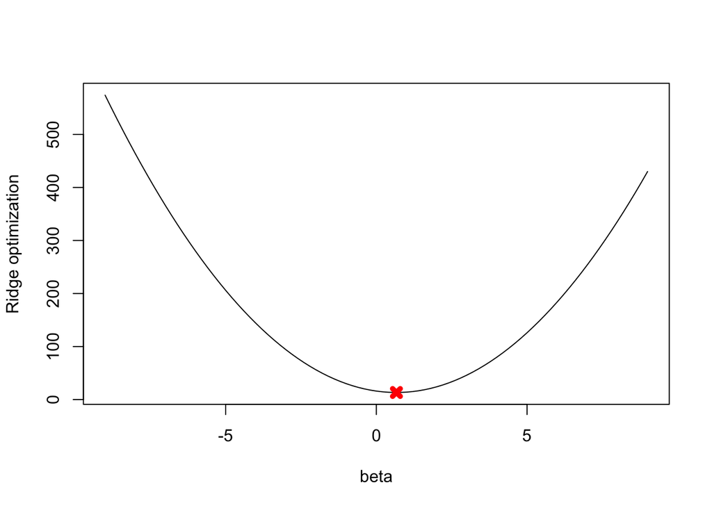

```r
lambda <- 5
y <- 4
fn <- function(beta) {
  (y - beta)^2 + lambda * beta^2
}
plot(seq(-9, 9, 0.2), fn(seq(-9, 9, 0.2)), type = "l",
     xlab = "beta", ylab = "Ridge optimization")
beta.est <- y / (1 + lambda)
points(beta.est, (y - beta.est)^2 + lambda * beta.est^2,
       col = "red", pch = 4, lwd = 5)
```

From the plot, the function is minimized at β=y/(1+λ).

### 6-(b):

Equation 6.13 is:

$$\sum_{j=1}^p(y_j - \beta_j)^2 + \lambda\sum_{j=1}^p|\beta_j|$$

Equation 6.15 is:

$$\hat{\beta}_j^L = \begin{cases}
y_j - \lambda/2 &\mbox{if } y_j > \lambda/2; \\
y_j + \lambda/2 &\mbox{if } y_j < -\lambda/2; \\
0 &\mbox{if } |y_j| \le \lambda/2;
\end{cases}$$

For $\lambda = 5$ and $y = 4$, the top case applies.

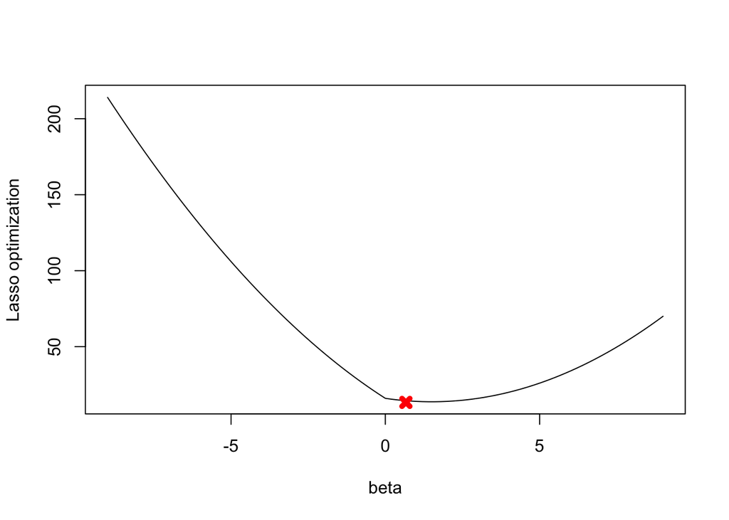

```r
lambda <- 5
y <- 4
fn <- function(beta) {
  (y - beta)^2 + lambda * abs(beta)
}
plot(seq(-9, 9, 0.2), fn(seq(-9, 9, 0.2)), type = "l",
     xlab = "beta", ylab = "Lasso optimization")
beta.est_l <- y / (1 + lambda)
points(beta.est_l, (y - beta.est_l)^2 + lambda * beta.est_l^2,
       col = "red", pch = 4, lwd = 5)
```

From the plot, the function is minimized at β=y−λ/2 when y>λ/2.

## 8

### (a) Generate the Data

```r
# library all packages for 8,10,11

library(leaps)
library(glmnet)
library(ncvreg)
library(SIS)
library(MASS)
library(ISLR)

set.seed(11)
n <- 100
X <- rnorm(n)
ep <- rnorm(n, mean = 0, sd = 1)
```

### (b) Generate Response Variable

```r
# Define coefficients
beta0 <- 2
beta1 <- 7
beta2 <- -5
beta3 <- 6

Y <- beta0 + beta1*X + beta2*X^2 + beta3*X^3 + ep
```

### (c) Best Subset Selection

We find that, with Cp we pick the 5-variables model, with BIC we pick the 4-variables model, and with adjusted R2 we pick the 5-variables model.

```r
data_8c <- data.frame(X, Y)

best_subset_8c <- regsubsets(Y ~ X + I(X^2) + I(X^3) + I(X^4) + I(X^5) + I(X^6) + I(X^7) + I(X^8) + I(X^9) + I(X^10),
                             data = data_8c,
                             nvmax = 10)

best_summary_8c <- summary(best_subset_8c)
best_summary_8c
```

```
## Subset selection object
## Call: regsubsets.formula(Y ~ X + I(X^2) + I(X^3) + I(X^4) + I(X^5) +
##     I(X^6) + I(X^7) + I(X^8) + I(X^9) + I(X^10), data = data_8c,
##     nvmax = 10)
## 10 Variables  (and intercept)
##         Forced in Forced out
## X           FALSE      FALSE
## I(X^2)      FALSE      FALSE
## I(X^3)      FALSE      FALSE
## I(X^4)      FALSE      FALSE
## I(X^5)      FALSE      FALSE
## I(X^6)      FALSE      FALSE
## I(X^7)      FALSE      FALSE
## I(X^8)      FALSE      FALSE
## I(X^9)      FALSE      FALSE
## I(X^10)     FALSE      FALSE
## 1 subsets of each size up to 10
## Selection Algorithm: exhaustive
##           X   I(X^2) I(X^3) I(X^4) I(X^5) I(X^6) I(X^7) I(X^8) I(X^9) I(X^10)
## 1  ( 1 )  " " " "    "*"    " "    " "    " "    " "    " "    " "    " "
## 2  ( 1 )  " " "*"    "*"    " "    " "    " "    " "    " "    " "    " "
## 3  ( 1 )  "*" "*"    "*"    " "    " "    " "    " "    " "    " "    " "
## 4  ( 1 )  "*" "*"    "*"    "*"    " "    " "    " "    " "    " "    " "
## 5  ( 1 )  "*" "*"    "*"    " "    " "    " "    " "    "*"    " "    "*"
## 6  ( 1 )  "*" "*"    "*"    " "    " "    "*"    " "    "*"    " "    "*"
## 7  ( 1 )  "*" "*"    "*"    "*"    "*"    " "    "*"    " "    "*"    " "
## 8  ( 1 )  "*" "*"    "*"    " "    "*"    " "    "*"    "*"    "*"    "*"
## 9  ( 1 )  "*" "*"    "*"    " "    "*"    "*"    "*"    "*"    "*"    "*"
## 10  ( 1 ) "*" "*"    "*"    "*"    "*"    "*"    "*"    "*"    "*"    "*"
```

```r
# Find best models based on Cp, BIC, and Adjusted R²
best_cp_8c <- which.min(best_summary_8c$cp)
best_cp_8c
```

```
## [1] 5
```

```r
best_bic_8c <- which.min(best_summary_8c$bic)
best_bic_8c
```

```
## [1] 4
```

```r
best_adj_r2_8c <- which.max(best_summary_8c$adjr2)
best_adj_r2_8c
```

```
## [1] 5
```

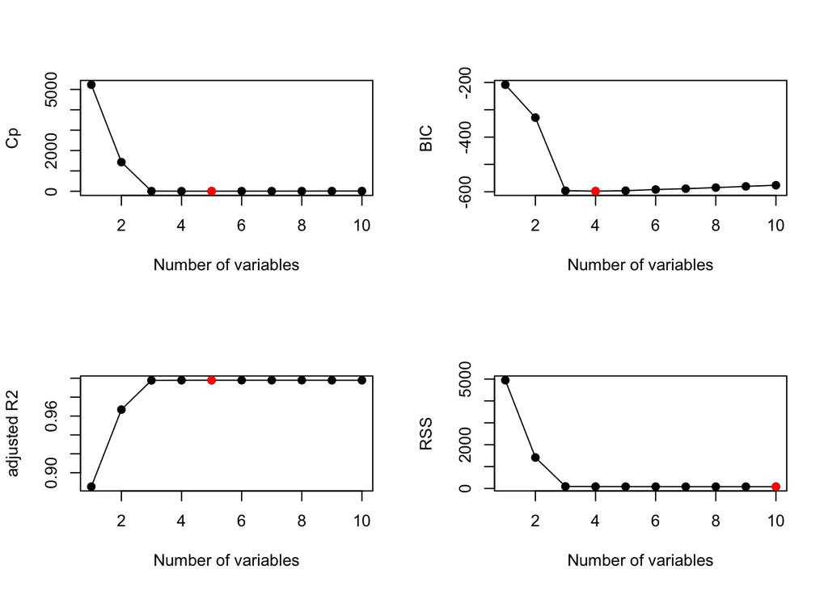

```r
# Plot selection criteria
# I used "type = "o"" to link every point to a line

par( mfrow=c(2,2) )

plot( best_summary_8c$cp,
      xlab="Number of variables", ylab="Cp", pch=19, type = "o" )
points(best_cp_8c, best_summary_8c$cp[best_cp_8c],
       col = "red", pch = 19)

plot( best_summary_8c$bic,
      xlab="Number of variables", ylab="BIC", pch=19, type = "o" )
points(best_bic_8c, best_summary_8c$bic[best_bic_8c],
       col = "red", pch = 19)

plot( best_summary_8c$adjr2,
      xlab="Number of variables", ylab="adjusted R2", pch=19, type = "o" )
points(best_adj_r2_8c, best_summary_8c$adjr2[best_adj_r2_8c],
       col = "red", pch = 19)

plot( best_summary_8c$rss,
      xlab="Number of variables", ylab="RSS",pch=19, type = "o" )
best_rss_8c <- which.min(best_summary_8c$rss)
points(best_rss_8c, best_summary_8c$rss[best_rss_8c],
       col = "red", pch = 19)
```

```r
par( mfrow=c(1,1) )

# Extract the coefficients of the best model
coef(best_subset_8c, best_cp_8c)
```

```
##  (Intercept)            X       I(X^2)       I(X^3)       I(X^8)      I(X^10)
##  2.440236257  6.807436739 -5.651819765  6.110017321  0.039763551 -0.006812396
```

```r
coef(best_subset_8c, best_bic_8c)
```

```
## (Intercept)           X      I(X^2)      I(X^3)      I(X^4)
##   2.4215888   6.9362648  -5.6698638   6.0118848   0.1377465
```

```r
coef(best_subset_8c, best_adj_r2_8c)
```

```
##  (Intercept)            X       I(X^2)       I(X^3)       I(X^8)      I(X^10)
##  2.440236257  6.807436739 -5.651819765  6.110017321  0.039763551 -0.006812396
```

```r
cat("Best Cp is: ", best_cp_8c,
    "according to best Cp, the coefficients are:", coef(best_subset_8c, best_cp_8c), "\n")
```

```
## Best Cp is:  5 according to best Cp, the coefficients are: 2.440236 6.807437 -5.65182 6.110017 0.03976355 -0.006812396
```

```r
cat("Best BIC is: ", best_bic_8c,
    "according to best BIC, the coefficients are:", coef(best_subset_8c, best_bic_8c), "\n")
```

```
## Best BIC is:  4 according to best BIC, the coefficients are: 2.421589 6.936265 -5.669864 6.011885 0.1377465
```

```r
cat("Best adjusted R2 is: ", best_adj_r2_8c,
    "according to best adjusted R2, the coefficients are:",
    coef(best_subset_8c, best_adj_r2_8c), "\n")
```

```
## Best adjusted R2 is:  5 according to best adjusted R2, the coefficients are: 2.440236 6.807437 -5.65182 6.110017 0.03976355 -0.006812396
```

### (d) Forward & Backward Stepwise Selection

Compared the results of three methods, best subset selection, forward selection and backward selection, I found the model size selected are slightly different. Even in the same model size selected by different methods, the selected variables and their coefficients are different. But there are several high-frequently selected variables like X, (X^2), (X^3), (X^8), (X^10), indicating those variables are very likely important.

Best subset selection: with Cp we pick the 5-variables model, with BIC we pick the 4-variables model, and with adjusted R2 we pick the 5-variables model.

Forward selection: with Cp we pick the 4-variables model, with BIC we pick the 4-variables model, and with adjusted R2 we pick the 7-variables model.

Backward selection: with Cp we pick the 4-variables model, with BIC we pick the 4-variables model, and with adjusted R2 we pick the 8-variables model.

With BIC, three selection methods all pick the 4-variables model.

With Cp, best subset selection picks the 5-variables model while forward and backward selection pick the 4-variables model - a slight difference.

With adjusted R2, the differences between the three selection methods are even greater. Best subset selection picks the 5-variables model, forward selection picks the 7-variables model and backward selection picks the 8-variables model.

```r
# Forward selection
forward_8d <- regsubsets(Y ~ X + I(X^2) + I(X^3) + I(X^4) + I(X^5) + I(X^6) + I(X^7) + I(X^8) + I(X^9) + I(X^10),
                         data = data_8c,
                         method = "forward", nvmax = 10)
summary(forward_8d)
```

```
## Subset selection object
## Call: regsubsets.formula(Y ~ X + I(X^2) + I(X^3) + I(X^4) + I(X^5) +
##     I(X^6) + I(X^7) + I(X^8) + I(X^9) + I(X^10), data = data_8c,
##     method = "forward", nvmax = 10)
## 10 Variables  (and intercept)
##         Forced in Forced out
## X           FALSE      FALSE
## I(X^2)      FALSE      FALSE
## I(X^3)      FALSE      FALSE
## I(X^4)      FALSE      FALSE
## I(X^5)      FALSE      FALSE
## I(X^6)      FALSE      FALSE
## I(X^7)      FALSE      FALSE
## I(X^8)      FALSE      FALSE
## I(X^9)      FALSE      FALSE
## I(X^10)     FALSE      FALSE
## 1 subsets of each size up to 10
## Selection Algorithm: forward
##           X   I(X^2) I(X^3) I(X^4) I(X^5) I(X^6) I(X^7) I(X^8) I(X^9) I(X^10)
## 1  ( 1 )  " " " "    "*"    " "    " "    " "    " "    " "    " "    " "
## 2  ( 1 )  " " "*"    "*"    " "    " "    " "    " "    " "    " "    " "
## 3  ( 1 )  "*" "*"    "*"    " "    " "    " "    " "    " "    " "    " "
## 4  ( 1 )  "*" "*"    "*"    "*"    " "    " "    " "    " "    " "    " "
## 5  ( 1 )  "*" "*"    "*"    "*"    " "    " "    " "    " "    " "    "*"
## 6  ( 1 )  "*" "*"    "*"    "*"    " "    " "    " "    "*"    " "    "*"
## 7  ( 1 )  "*" "*"    "*"    "*"    " "    "*"    " "    "*"    " "    "*"
## 8  ( 1 )  "*" "*"    "*"    "*"    " "    "*"    "*"    "*"    " "    "*"
## 9  ( 1 )  "*" "*"    "*"    "*"    "*"    "*"    "*"    "*"    " "    "*"
## 10  ( 1 ) "*" "*"    "*"    "*"    "*"    "*"    "*"    "*"    "*"    "*"
```

```r
# Backward selection
backward_8d <- regsubsets(Y ~ X + I(X^2) + I(X^3) + I(X^4) + I(X^5) + I(X^6) + I(X^7) + I(X^8) + I(X^9) + I(X^10),
                          data = data_8c,
                          method = "backward", nvmax = 10)
summary(backward_8d)
```

```
## Subset selection object
## Call: regsubsets.formula(Y ~ X + I(X^2) + I(X^3) + I(X^4) + I(X^5) +
##     I(X^6) + I(X^7) + I(X^8) + I(X^9) + I(X^10), data = data_8c,
##     method = "backward", nvmax = 10)
## 10 Variables  (and intercept)
##         Forced in Forced out
## X           FALSE      FALSE
## I(X^2)      FALSE      FALSE
## I(X^3)      FALSE      FALSE
## I(X^4)      FALSE      FALSE
## I(X^5)      FALSE      FALSE
## I(X^6)      FALSE      FALSE
## I(X^7)      FALSE      FALSE
## I(X^8)      FALSE      FALSE
## I(X^9)      FALSE      FALSE
## I(X^10)     FALSE      FALSE
## 1 subsets of each size up to 10
## Selection Algorithm: backward
##           X   I(X^2) I(X^3) I(X^4) I(X^5) I(X^6) I(X^7) I(X^8) I(X^9) I(X^10)
## 1  ( 1 )  " " " "    "*"    " "    " "    " "    " "    " "    " "    " "
## 2  ( 1 )  " " "*"    "*"    " "    " "    " "    " "    " "    " "    " "
## 3  ( 1 )  "*" "*"    "*"    " "    " "    " "    " "    " "    " "    " "
## 4  ( 1 )  "*" "*"    "*"    " "    " "    " "    " "    "*"    " "    " "
## 5  ( 1 )  "*" "*"    "*"    " "    " "    " "    " "    "*"    "*"    " "
## 6  ( 1 )  "*" "*"    "*"    " "    " "    " "    "*"    "*"    "*"    " "
## 7  ( 1 )  "*" "*"    "*"    " "    "*"    " "    "*"    "*"    "*"    " "
## 8  ( 1 )  "*" "*"    "*"    " "    "*"    " "    "*"    "*"    "*"    "*"
## 9  ( 1 )  "*" "*"    "*"    " "    "*"    "*"    "*"    "*"    "*"    "*"
## 10  ( 1 ) "*" "*"    "*"    "*"    "*"    "*"    "*"    "*"    "*"    "*"
```

```r
# To compare the results of three selection methods, I did (c) again, got the best model for each selection obtained according to Cp, BIC, and adjusted R2 and the coefficients of the best model obtained.

# Forward selection results

best_cp_forward <- which.min(summary(forward_8d)$cp)
best_cp_forward
```

```
## [1] 4
```

```r
coef(forward_8d, best_cp_forward)
```

```
## (Intercept)           X      I(X^2)      I(X^3)      I(X^4)
##   2.4215888   6.9362648  -5.6698638   6.0118848   0.1377465
```

```r
best_bic_forward <- which.min(summary(forward_8d)$bic)
best_bic_forward
```

```
## [1] 4
```

```r
coef(forward_8d, best_bic_forward)
```

```
## (Intercept)           X      I(X^2)      I(X^3)      I(X^4)
##   2.4215888   6.9362648  -5.6698638   6.0118848   0.1377465
```

```r
best_adj_r2_forward <- which.max(summary(forward_8d)$adjr2)
best_adj_r2_forward
```

```
## [1] 7
```

```r
coef(forward_8d, best_adj_r2_forward)
```

```
## (Intercept)           X      I(X^2)      I(X^3)      I(X^4)      I(X^6)
##  2.50130625  6.78790955 -6.59239365  6.12385867  1.88950036 -1.18588387
##      I(X^8)     I(X^10)
##  0.32381491 -0.02970758
```

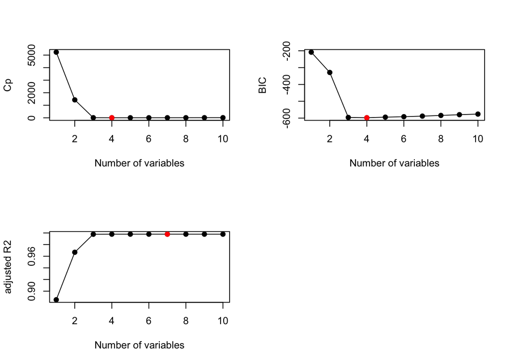

```r
par( mfrow=c(2,2) )

plot( summary(forward_8d)$cp,
      xlab="Number of variables", ylab="Cp", pch=19, type = "o" )
points(best_cp_forward, summary(forward_8d)$cp[best_cp_forward],
       col = "red", pch = 19)

plot( summary(forward_8d)$bic,
      xlab="Number of variables", ylab="BIC", pch=19, type = "o" )
points(best_bic_forward, summary(forward_8d)$bic[best_bic_forward],
       col = "red", pch = 19)

plot( summary(forward_8d)$adjr2,
      xlab="Number of variables", ylab="adjusted R2", pch=19, type = "o" )
points(best_adj_r2_forward, summary(forward_8d)$adjr2[best_adj_r2_forward],
       col = "red", pch = 19)

par( mfrow=c(1,1) )
```

```r
# Backward selection results

best_cp_backward <- which.min(summary(backward_8d)$cp)
best_cp_backward
```

```
## [1] 4
```

```r
coef(backward_8d, best_cp_backward)
```

```
##  (Intercept)            X       I(X^2)       I(X^3)       I(X^8)
##  2.345066027  6.970861916 -5.367658301  5.992670582  0.003084808
```

```r
best_bic_backward <- which.min(summary(backward_8d)$bic)
best_bic_backward
```

```
## [1] 4
```

```r
coef(backward_8d, best_bic_backward)
```

```
##  (Intercept)            X       I(X^2)       I(X^3)       I(X^8)
##  2.345066027  6.970861916 -5.367658301  5.992670582  0.003084808
```

```r
best_adj_r2_backward <- which.max(summary(backward_8d)$adjr2)
best_adj_r2_backward
```

```
## [1] 8
```

```r
coef(backward_8d, best_adj_r2_backward)
```

```
##  (Intercept)            X       I(X^2)       I(X^3)       I(X^5)       I(X^7)
##  2.427284751  6.395111850 -5.586116311  7.732408318 -1.510508175  0.480855294
##       I(X^8)       I(X^9)      I(X^10)
##  0.029622916 -0.048126313 -0.004579645
```

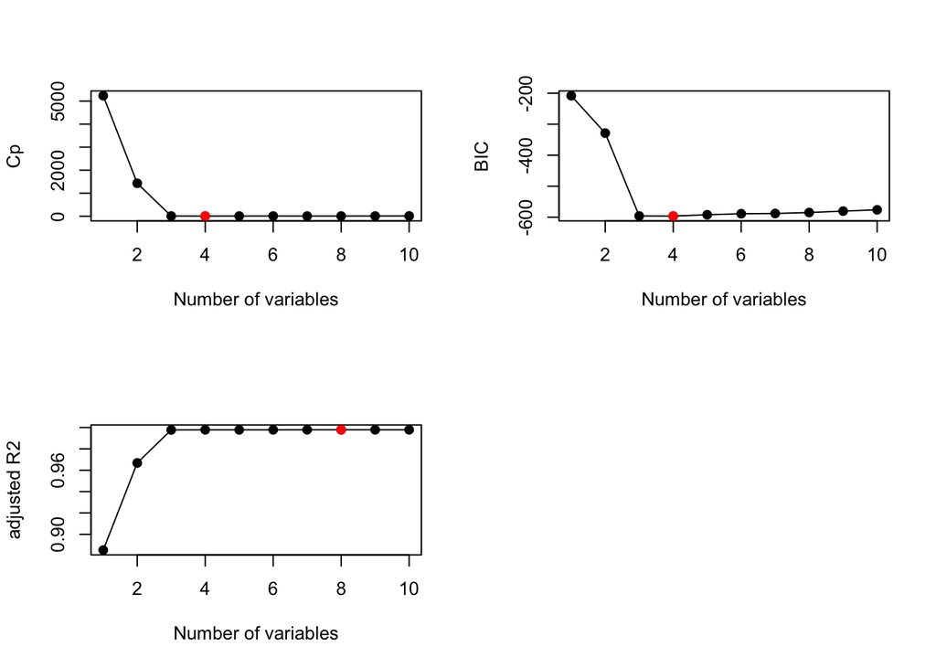

```r
par( mfrow=c(2,2) )

plot( summary(backward_8d)$cp,
      xlab="Number of variables", ylab="Cp", pch=19, type = "o" )
points(best_cp_backward, summary(backward_8d)$cp[best_cp_backward],
       col = "red", pch = 19)

plot( summary(backward_8d)$bic,
      xlab="Number of variables", ylab="BIC", pch=19, type = "o" )
points(best_bic_backward, summary(backward_8d)$bic[best_bic_backward],
       col = "red", pch = 19)

plot( summary(backward_8d)$adjr2,
      xlab="Number of variables", ylab="adjusted R2", pch=19, type = "o" )
points(best_adj_r2_backward, summary(backward_8d)$adjr2[best_adj_r2_backward],
       col = "red", pch = 19)

par( mfrow=c(1,1) )
```

### (e) Lasso Regression with Cross-Validation

The best lambda is 0.1177742

After refitting lasso model with the best lambda, The lasso method picks X, X^2 and X^3 as variables for the model.

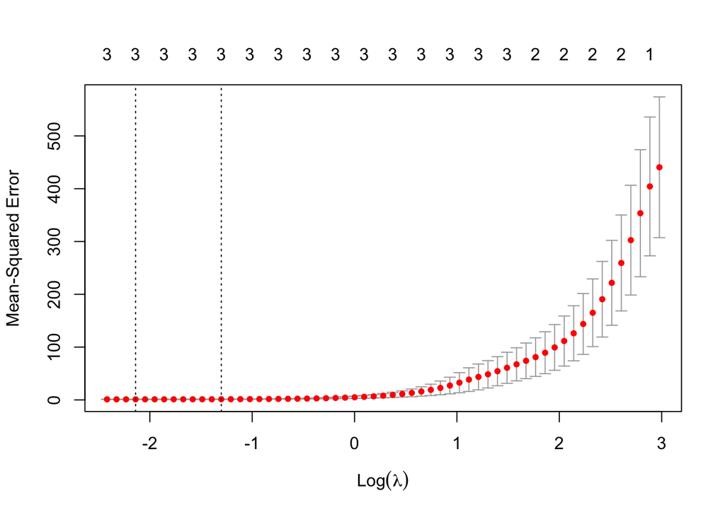

```r
grid =10 ^ seq (10, -2, length = 100)

X_mat <- model.matrix(Y ~ X + I(X^2) + I(X^3) + I(X^4) + I(X^5) + I(X^6) + I(X^7) + I(X^8) + I(X^9) + I(X^10), data = data_8c)[,-1]
Y_vec <- data_8c$Y

cv_8e <- cv.glmnet(X_mat, Y_vec, alpha = 1)
plot(cv_8e)
```

```r
best_lamb_8e <- cv_8e$lambda.min
best_lamb_8e
```

```
## [1] 0.1177742
```

```r
lasso_coef <- coef(cv_8e, s = best_lamb_8e)
print(lasso_coef)
```

```
## 11 x 1 sparse Matrix of class "dgCMatrix"
##                    s1
## (Intercept)  2.097204
## X            6.867760
## I(X^2)      -4.988379
## I(X^3)       6.013279
## I(X^4)       .
## I(X^5)       .
## I(X^6)       .
## I(X^7)       .
## I(X^8)       .
## I(X^9)       .
## I(X^10)      .
```

```r
# refit lasso model using the best lambda

out_8e <- glmnet(X_mat, Y_vec, alpha = 1)
lasso.coef_8e <- predict(out_8e, type = "coefficients", s = best_lamb_8e)[1:11,]

lasso.coef_8e
```

```
## (Intercept)           X      I(X^2)      I(X^3)      I(X^4)      I(X^5)
##    2.097204    6.867760   -4.988379    6.013279    0.000000    0.000000
##      I(X^6)      I(X^7)      I(X^8)      I(X^9)     I(X^10)
##    0.000000    0.000000    0.000000    0.000000    0.000000
```

```r
lasso.coef_8e[lasso.coef_8e !=0]
```

```
## (Intercept)           X      I(X^2)      I(X^3)
##    2.097204    6.867760   -4.988379    6.013279
```

### (f) New Model

```r
# Define coefficients
beta0 <- 2
beta7 <- 3

# Generate new response variable
Y_8f <- beta0 + beta7 * X^7 + ep

# Create new dataset
data_8f <- data.frame(X, Y_8f)

# Perform best subset selection again
best_subset_8f <- regsubsets(Y_8f ~ X + I(X^2) + I(X^3) + I(X^4) + I(X^5) + I(X^6) + I(X^7) + I(X^8) + I(X^9) + I(X^10),
                             data = data_8f)
summary(best_subset_8f)
```

```
## Subset selection object
## Call: regsubsets.formula(Y_8f ~ X + I(X^2) + I(X^3) + I(X^4) + I(X^5) +
##     I(X^6) + I(X^7) + I(X^8) + I(X^9) + I(X^10), data = data_8f)
## 10 Variables  (and intercept)
##         Forced in Forced out
## X           FALSE      FALSE
## I(X^2)      FALSE      FALSE
## I(X^3)      FALSE      FALSE
## I(X^4)      FALSE      FALSE
## I(X^5)      FALSE      FALSE
## I(X^6)      FALSE      FALSE
## I(X^7)      FALSE      FALSE
## I(X^8)      FALSE      FALSE
## I(X^9)      FALSE      FALSE
## I(X^10)     FALSE      FALSE
## 1 subsets of each size up to 8
## Selection Algorithm: exhaustive
##          X   I(X^2) I(X^3) I(X^4) I(X^5) I(X^6) I(X^7) I(X^8) I(X^9) I(X^10)
## 1  ( 1 ) " " " "    " "    " "    " "    " "    "*"    " "    " "    " "
## 2  ( 1 ) " " "*"    " "    " "    " "    " "    "*"    " "    " "    " "
## 3  ( 1 ) " " "*"    " "    "*"    " "    " "    "*"    " "    " "    " "
## 4  ( 1 ) " " " "    " "    "*"    " "    " "    "*"    "*"    " "    "*"
## 5  ( 1 ) " " "*"    " "    " "    " "    "*"    "*"    "*"    " "    "*"
## 6  ( 1 ) " " "*"    " "    "*"    " "    "*"    "*"    "*"    " "    "*"
## 7  ( 1 ) "*" "*"    " "    "*"    " "    "*"    "*"    "*"    " "    "*"
## 8  ( 1 ) "*" "*"    "*"    " "    "*"    " "    "*"    "*"    "*"    "*"
```

```r
coef(best_subset_8f, which.min(summary(best_subset_8f)$cp))
```

```
## (Intercept)      I(X^4)      I(X^7)      I(X^8)     I(X^10)
##  2.31952099 -0.43305778  3.00443826  0.08180307 -0.01274959
```

```r
coef(best_subset_8f, which.min(summary(best_subset_8f)$bic))
```

```
## (Intercept)      I(X^7)
##    2.119193    3.001060
```

```r
coef(best_subset_8f, which.min(summary(best_subset_8f)$adjr2))
```

```
## (Intercept)      I(X^7)
##    2.119193    3.001060
```

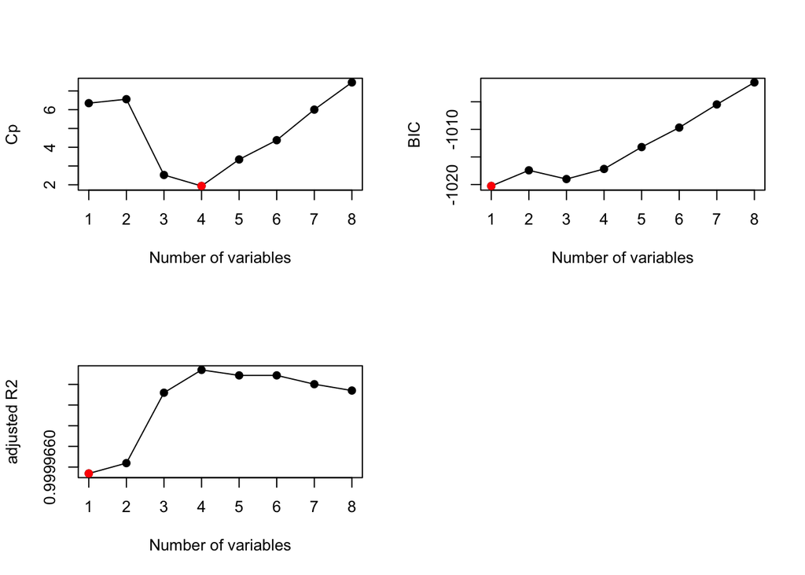

```r
par( mfrow=c(2,2) )

plot( summary(best_subset_8f)$cp,
      xlab="Number of variables", ylab="Cp", pch=19, type = "o" )
points(which.min(summary(best_subset_8f)$cp),
       summary(best_subset_8f)$cp[which.min(summary(best_subset_8f)$cp)],
       col = "red", pch = 19)

plot( summary(best_subset_8f)$bic,
      xlab="Number of variables", ylab="BIC", pch=19, type = "o" )
points(which.min(summary(best_subset_8f)$bic),
       summary(best_subset_8f)$bic[which.min(summary(best_subset_8f)$bic)],
       col = "red", pch = 19)

plot( summary(best_subset_8f)$adjr2,
      xlab="Number of variables", ylab="adjusted R2", pch=19, type = "o" )
points(which.min(summary(best_subset_8f)$adjr2),
       summary(best_subset_8f)$adjr2[which.min(summary(best_subset_8f)$adjr2)],
       col = "red", pch = 19)

par( mfrow=c(1,1) )
```

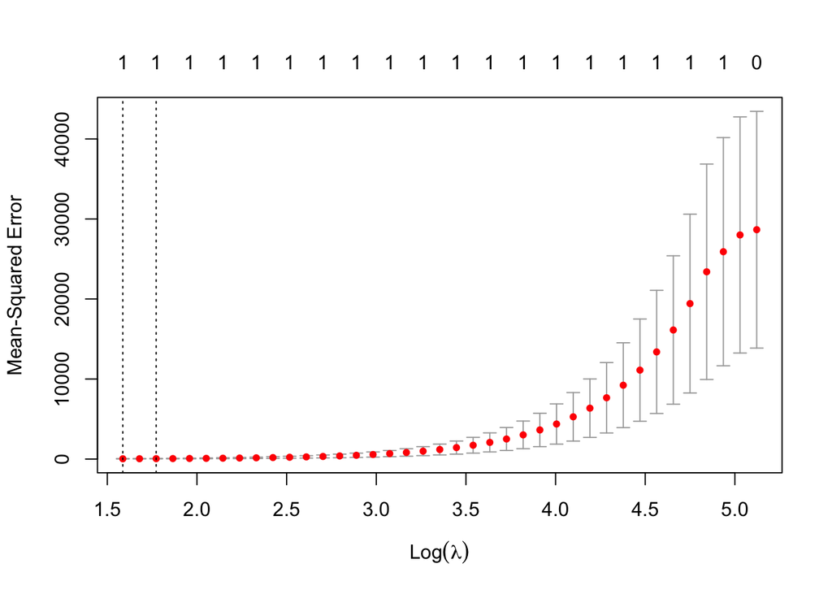

```r
# Perform Lasso regression again
X_mat_2 <- model.matrix(Y ~ X + I(X^2) + I(X^3) + I(X^4) + I(X^5) + I(X^6) + I(X^7) + I(X^8) + I(X^9) + I(X^10), data = data_8f)[,-1]

cv_8f <- cv.glmnet(X_mat_2, data_8f$Y, alpha = 1)
plot(cv_8f)
```

```r
out_8f <- glmnet(X_mat_2, data_8f$Y, alpha = 1)
lasso.coef_8f <- predict(out_8f, type = "coefficients",
                         s = cv_8f$lambda.min)[1:11,]

lasso.coef_8f
```

```
## (Intercept)           X      I(X^2)      I(X^3)      I(X^4)      I(X^5)
##    2.389977    0.000000    0.000000    0.000000    0.000000    0.000000
##      I(X^6)      I(X^7)      I(X^8)      I(X^9)     I(X^10)
##    0.000000    2.913578    0.000000    0.000000    0.000000
```

```r
lasso.coef_8f[lasso.coef_8f !=0]
```

```
## (Intercept)      I(X^7)
##    2.389977    2.913578
```

## 10

### (a) Generate the dataset

```r
set.seed(11)

n <- 1000
p <- 20

X_10a <- matrix(rnorm(n * p), n, p)

# Define true beta where some are exactly 0.
beta_true <- rep(0, 20)
beta_true[1:5] <- c(2, -5, 100, 7, 9)

ep_10a <- rnorm(n, mean = 0, sd = 1)

Y_10a <- X_10a %*% beta_true + ep_10a

data_10a <- data.frame(X_10a, Y_10a)
```

### (b) training data (100) and test data (900)

```r
set.seed(11)
idx <- sample(n, 100)
train_data_10b <- data_10a[idx, ]
test_data_10b <- data_10a[-idx, ]
```

### (c) Perform Best Subset Selection and Plot Training MSE

```r
best_subset_10c <- regsubsets(Y_10a ~ .,data = train_data_10b, nvmax = p)

summary(best_subset_10c)
```

```
## Subset selection object
## Call: regsubsets.formula(Y_10a ~ ., data = train_data_10b, nvmax = p)
## 20 Variables  (and intercept)
##     Forced in Forced out
## X1      FALSE      FALSE
## X2      FALSE      FALSE
## X3      FALSE      FALSE
## X4      FALSE      FALSE
## X5      FALSE      FALSE
## X6      FALSE      FALSE
## X7      FALSE      FALSE
## X8      FALSE      FALSE
## X9      FALSE      FALSE
## X10     FALSE      FALSE
## X11     FALSE      FALSE
## X12     FALSE      FALSE
## X13     FALSE      FALSE
## X14     FALSE      FALSE
## X15     FALSE      FALSE
## X16     FALSE      FALSE
## X17     FALSE      FALSE
## X18     FALSE      FALSE
## X19     FALSE      FALSE
## X20     FALSE      FALSE
## 1 subsets of each size up to 20
## Selection Algorithm: exhaustive
##           X1  X2  X3  X4  X5  X6  X7  X8  X9  X10 X11 X12 X13 X14 X15 X16 X17
## 1  ( 1 )  " " " " "*" " " " " " " " " " " " " " " " " " " " " " " " " " " " "
## 2  ( 1 )  " " " " "*" " " "*" " " " " " " " " " " " " " " " " " " " " " " " "
## 3  ( 1 )  " " " " "*" "*" "*" " " " " " " " " " " " " " " " " " " " " " " " "
## 4  ( 1 )  " " "*" "*" "*" "*" " " " " " " " " " " " " " " " " " " " " " " " "
## 5  ( 1 )  "*" "*" "*" "*" "*" " " " " " " " " " " " " " " " " " " " " " " " "
## 6  ( 1 )  "*" "*" "*" "*" "*" " " " " "*" " " " " " " " " " " " " " " " " " "
## 7  ( 1 )  "*" "*" "*" "*" "*" " " " " "*" "*" " " " " " " " " " " " " " " " "
## 8  ( 1 )  "*" "*" "*" "*" "*" " " " " "*" "*" " " " " " " " " "*" " " " " " "
## 9  ( 1 )  "*" "*" "*" "*" "*" " " " " "*" "*" " " " " " " "*" "*" " " " " " "
## 10  ( 1 ) "*" "*" "*" "*" "*" " " " " "*" "*" " " " " "*" "*" "*" " " " " " "
## 11  ( 1 ) "*" "*" "*" "*" "*" " " " " "*" "*" " " " " "*" "*" "*" " " "*" " "
## 12  ( 1 ) "*" "*" "*" "*" "*" " " " " "*" "*" " " " " "*" "*" "*" " " "*" " "
## 13  ( 1 ) "*" "*" "*" "*" "*" " " " " "*" "*" " " " " "*" "*" "*" " " "*" "*"
```

[output cut: 13 more lines]

```
## 6  ( 1 )  " " " " " "
## 7  ( 1 )  " " " " " "
## 8  ( 1 )  " " " " " "
## 9  ( 1 )  " " " " " "
## 10  ( 1 ) " " " " " "
## 11  ( 1 ) " " " " " "
## 12  ( 1 ) " " "*" " "
## 13  ( 1 ) " " "*" " "
## 14  ( 1 ) " " "*" " "
## 15  ( 1 ) " " "*" "*"
## 16  ( 1 ) " " "*" "*"
## 17  ( 1 ) " " "*" "*"
## 18  ( 1 ) " " "*" "*"
## 19  ( 1 ) "*" "*" "*"
## 20  ( 1 ) "*" "*" "*"
```

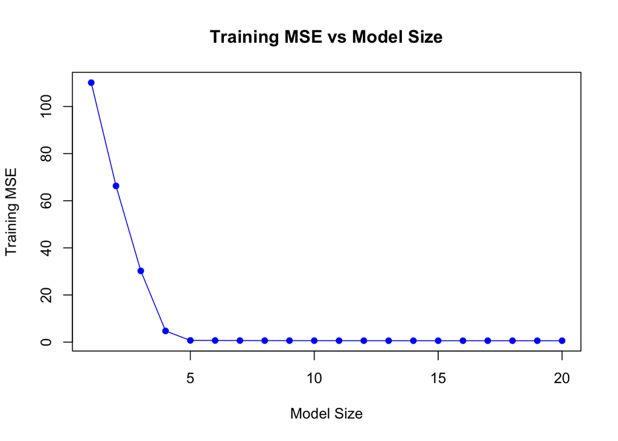

```r
plot(summary(best_subset_10c)$rss / nrow(train_data_10b),
     type = "o", col = "blue", pch = 16,
     xlab = "Model Size",
     ylab = "Training MSE",
     main = "Training MSE vs Model Size")
```

### (d) Plot Test MSE

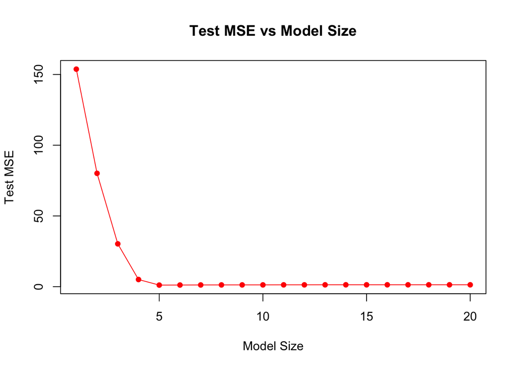

```r
test_mse_10d <- rep(NA, p)

test.mat <- model.matrix(Y_10a ~ ., data = test_data_10b)

for (i in 1:p) {
  coefi <- coef(best_subset_10c, id = i)
  pred_test <- test.mat[, names(coefi)] %*% coefi
  test_mse_10d[i] <- mean((test_data_10b$Y_10a - pred_test) ^ 2)
}

plot(1:p, test_mse_10d, type = "o", col = "red", pch = 16,
     xlab = "Model Size",
     ylab = "Test MSE",
     main = "Test MSE vs Model Size")
```

### (e) Determine Optimal Model Size

The test MSE is minimized at model size 5, an intermediate number of features.

This corresponds to the simulated data which has 5 non-zero coefficients.

```r
best_model_size_10e <- which.min(test_mse_10d)
cat("The test MSE is minimized at model size:", best_model_size_10e, "\n")
```

```
## The test MSE is minimized at model size: 5
```

```r
## If I change other 4 coefficients from 0 to very small value, the test MSE is still minimized at model size 5. ___ as below ##

set.seed(11)
dat <- matrix(rnorm(1000 * 20), nrow = 1000)
colnames(dat) <- paste0("b", 1:20)
beta <- rep(0, 20)
beta[1:9] <- c(2, -5, 3, 7, 9, 0.001, 0.05, -0.1, 0.1052)
y <- colSums((t(dat) * beta)) + rnorm(1000)
dat <- data.frame(dat)
dat$y <- y
train <- dat[1:100, ]
test <- dat[101:1000, ]

predict.regsubsets <-function (object ,newdata ,id ,...){
  form=as.formula (object$call [[2]])
 mat=model.matrix (form, newdata)
  coefi =coef(object ,id=id)
  xvars =names (coefi )
  mat[,xvars ]%*% coefi
  }

fit <- regsubsets(y ~ ., data = train, nvmax = 20)
summary(fit)
```

```
## Subset selection object
## Call: regsubsets.formula(y ~ ., data = train, nvmax = 20)
## 20 Variables  (and intercept)
##     Forced in Forced out
## b1      FALSE      FALSE
## b2      FALSE      FALSE
## b3      FALSE      FALSE
## b4      FALSE      FALSE
## b5      FALSE      FALSE
## b6      FALSE      FALSE
## b7      FALSE      FALSE
## b8      FALSE      FALSE
## b9      FALSE      FALSE
## b10     FALSE      FALSE
## b11     FALSE      FALSE
## b12     FALSE      FALSE
## b13     FALSE      FALSE
## b14     FALSE      FALSE
## b15     FALSE      FALSE
## b16     FALSE      FALSE
## b17     FALSE      FALSE
## b18     FALSE      FALSE
## b19     FALSE      FALSE
## b20     FALSE      FALSE
## 1 subsets of each size up to 20
## Selection Algorithm: exhaustive
##           b1  b2  b3  b4  b5  b6  b7  b8  b9  b10 b11 b12 b13 b14 b15 b16 b17
## 1  ( 1 )  " " " " " " " " "*" " " " " " " " " " " " " " " " " " " " " " " " "
## 2  ( 1 )  " " " " " " "*" "*" " " " " " " " " " " " " " " " " " " " " " " " "
## 3  ( 1 )  " " "*" " " "*" "*" " " " " " " " " " " " " " " " " " " " " " " " "
## 4  ( 1 )  " " "*" "*" "*" "*" " " " " " " " " " " " " " " " " " " " " " " " "
## 5  ( 1 )  "*" "*" "*" "*" "*" " " " " " " " " " " " " " " " " " " " " " " " "
## 6  ( 1 )  "*" "*" "*" "*" "*" " " " " " " " " " " " " " " " " " " " " " " " "
## 7  ( 1 )  "*" "*" "*" "*" "*" " " " " "*" " " " " " " " " " " " " " " "*" " "
## 8  ( 1 )  "*" "*" "*" "*" "*" " " " " "*" " " " " " " " " " " " " " " "*" " "
## 9  ( 1 )  "*" "*" "*" "*" "*" " " " " "*" "*" " " " " " " " " " " " " "*" " "
## 10  ( 1 ) "*" "*" "*" "*" "*" "*" " " "*" "*" " " " " " " " " " " " " "*" " "
## 11  ( 1 ) "*" "*" "*" "*" "*" "*" " " "*" "*" " " "*" " " " " " " " " "*" " "
## 12  ( 1 ) "*" "*" "*" "*" "*" "*" " " "*" "*" " " "*" " " " " " " " " "*" " "
## 13  ( 1 ) "*" "*" "*" "*" "*" "*" " " "*" "*" " " "*" " " "*" " " " " "*" " "
```

[output cut: 13 more lines]

```
## 6  ( 1 )  "*" " " " "
## 7  ( 1 )  " " " " " "
## 8  ( 1 )  "*" " " " "
## 9  ( 1 )  "*" " " " "
## 10  ( 1 ) "*" " " " "
## 11  ( 1 ) "*" " " " "
## 12  ( 1 ) "*" "*" " "
## 13  ( 1 ) "*" "*" " "
## 14  ( 1 ) "*" "*" " "
## 15  ( 1 ) "*" "*" " "
## 16  ( 1 ) "*" "*" " "
## 17  ( 1 ) "*" "*" " "
## 18  ( 1 ) "*" "*" " "
## 19  ( 1 ) "*" "*" " "
## 20  ( 1 ) "*" "*" "*"
```

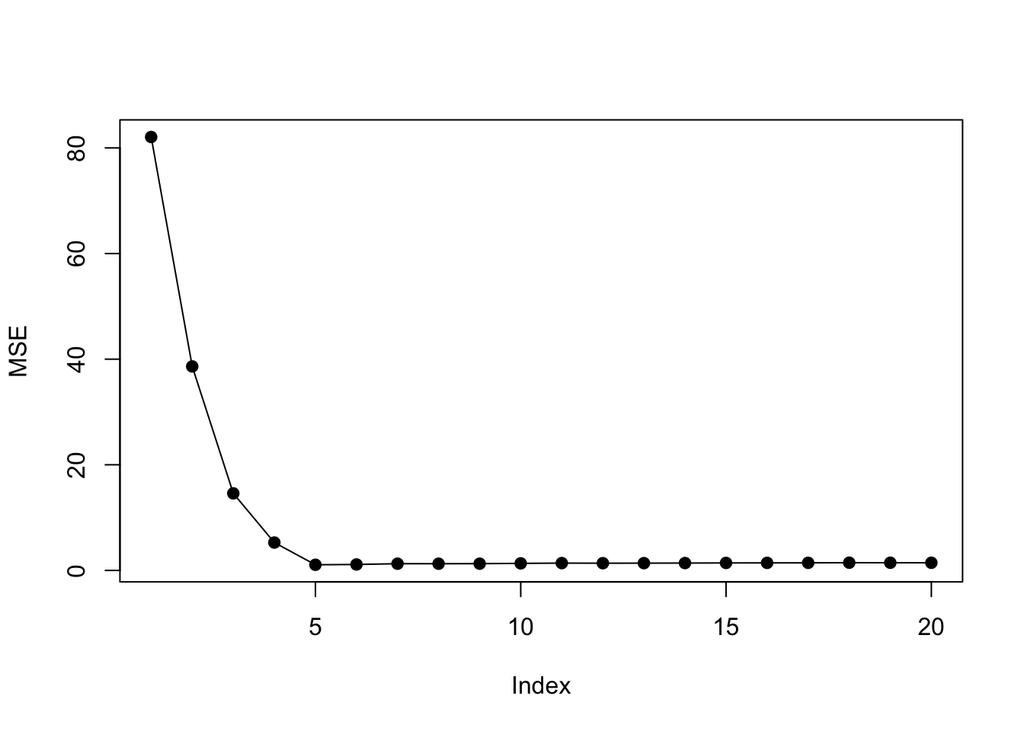

```r
mse <- sapply(1:20, function(i) mean((test$y - predict.regsubsets(fit, test, i))^2))
plot(mse, ylab = "MSE", type = "o", pch = 19)
```

```r
which.min(mse)
```

```
## [1] 5
```

### (f) Compare Selected Model to True Model

Compared the true model to the model at which the test set MSE is minimized, their coeﬀicient values are extremely close. It indicates that the coefficient values are well estimated.

```r
# Get selected model coefficients
best_model_coef_10f <- coef(best_subset_10c, id = best_model_size_10e)

# Compare with true beta
beta_estimates_10f <- rep(0, p)
names(beta_estimates_10f) <- colnames(X_10a)

# Fill in the estimated values
beta_estimates_10f[names(best_model_coef_10f)[-1]] <- best_model_coef_10f[-1]

# Comparison
beta_true
```

```
##  [1]   2  -5 100   7   9   0   0   0   0   0   0   0   0   0   0   0   0   0   0
## [20]   0
```

```r
beta_estimates_10f
```

```
##
##   0.000000   0.000000   0.000000   0.000000   0.000000   0.000000   0.000000
##
##   0.000000   0.000000   0.000000   0.000000   0.000000   0.000000   0.000000
##                                                                           X1
##   0.000000   0.000000   0.000000   0.000000   0.000000   0.000000   1.859931
##         X2         X3         X4         X5
##  -4.907659 100.057426   6.992893   8.885907
```

### (g) Plot Beta Error

From the Beta error plot, the error of the coefficient estimates is minimized when model size is 5. This corresponds to the point when test MSE was minimized.

As more features are added, the Beta error initially decreases but increases after the point model size = 5. This resembles the test MSE plot, confirming that models with excessive parameters poorly estimate coefficients.

```r
beta_error_10g <- rep(NA, p)

beta_true
```

```
##  [1]   2  -5 100   7   9   0   0   0   0   0   0   0   0   0   0   0   0   0   0
## [20]   0
```

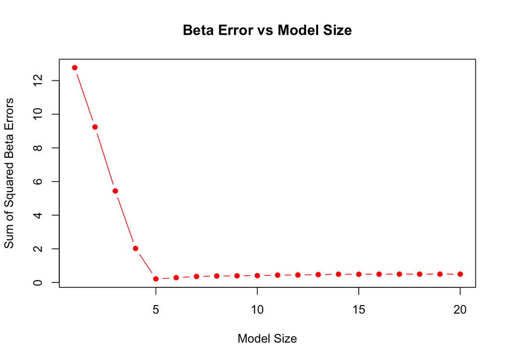

```r
colnames(X_10a) <- paste0("X", seq(1, 20))

for (r in 1:p) {
  coef_r <- coef(best_subset_10c, id = r)
  beta_est_r <- rep(0, p)
  names(beta_est_r) <- colnames(X_10a)
  beta_est_r[names(coef_r)[-1]] <- coef_r[-1]

  beta_error_10g[r] <- sqrt(sum((beta_true - beta_est_r) ^ 2))
}

# Plot Beta Error
plot(1:p, beta_error_10g, type = "b",
     col = "red", pch = 16,
     xlab = "Model Size",
     ylab = "Sum of Squared Beta Errors",
     main = "Beta Error vs Model Size")
```

## 11

Breast cancer gene expression data from The Cancer Genome Atlas (brca1.rds Download brca1.rds). This is a dataset with ultra-high dimensional covariates, i.e., . Split the data set into a training set and a test set. Standardize the continuous variables before carrying out variable selection, to make sure all the coefficients are on the same scale.

### Pre-processing

```r
data_11 <- readRDS("brca1.rds")
X <- data_11$X
Y <- data_11$y

# exclude missing values
X <- na.omit(X)
Y <- na.omit(Y)

# Standardize the continuous variables
X_scaled <- scale(X)

set.seed(11)
train=sample (c(TRUE, FALSE), nrow(X_scaled), rep=TRUE)
sum(train==TRUE)     ##Get the number of training observations
```

```
## [1] 265
```

```r
test=(!train )
sum(test==TRUE)    ##Get the number of testing observations
```

```
## [1] 271
```

```r
X_train <- X_scaled[train, ]
Y_train <- Y[train]
X_test <- X_scaled[test, ]
Y_test <- Y[test]
```

### (a)

1. Fit a lasso model on the training set, with chosen by cross validation. Report the test error obtained, along with the number of non-zero coefficient estimates.

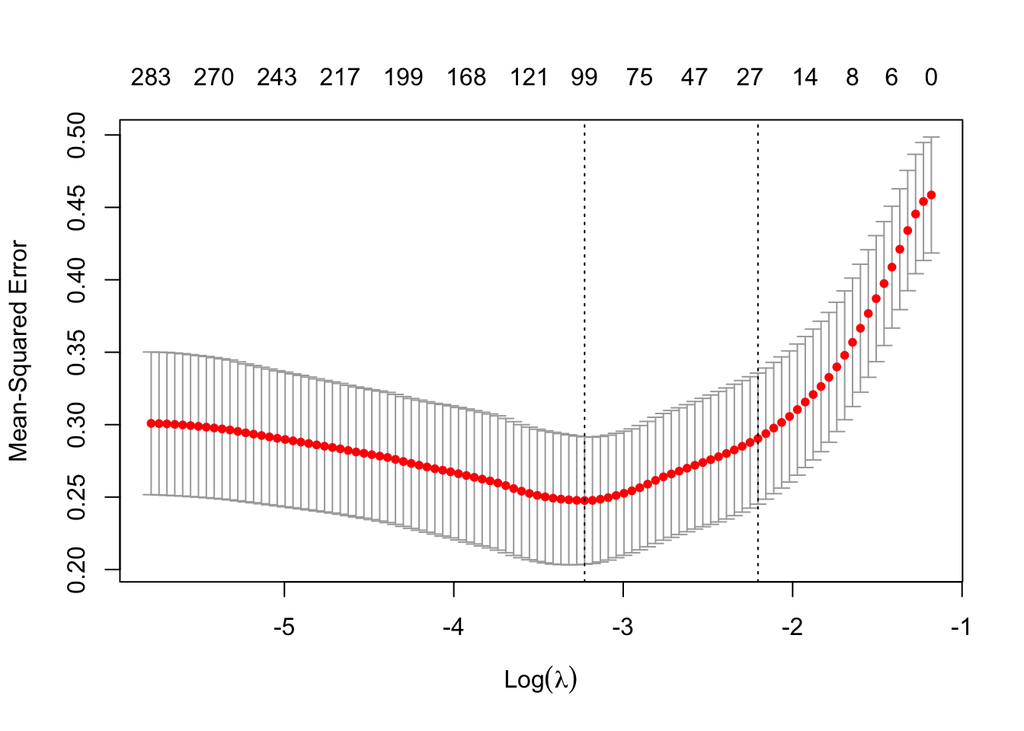

```r
lasso_mod_11a <- glmnet(X_train, Y_train, alpha = 1, lambda = grid)

cv_out_11a <- cv.glmnet(X_train, Y_train, alpha = 1)
plot(cv_out_11a)
```

```r
best_lam_11a <- cv_out_11a$lambda.min

lasso_pred_11a <- predict(lasso_mod_11a, s = best_lam_11a, newx = X_test)
test_error_lasso_11a <- mean((lasso_pred_11a - Y_test)^2)

out_11a <- glmnet(X_scaled, Y, alpha=1)
lasso_coef_11a <- predict(out_11a, type="coefficients",
                          s=best_lam_11a)[-1, ]

lasso_coef_11a[lasso_coef_11a !=0]
```

```
##         AASDH         ACYP2      ALDH18A1      ANKRD13B        ANKRD5
## -6.674421e-03 -9.600156e-03  7.425625e-04  9.196027e-04  4.962012e-03
##         AP3M1      ARHGAP19         ARIH1         ATAD1         BCAS2
##  8.711236e-03  1.783851e-02 -3.548440e-03  6.325183e-05 -7.690263e-03
##      C10orf76      C12orf48       C3orf10       C4orf14         CBLN3
##  2.796245e-02  1.106347e-05 -3.796649e-02 -1.539198e-02  1.289066e-02
##        CCDC56       CEACAM8         CENPK         CENPM         CENPQ
##  5.239300e-02  2.528488e-02  2.087007e-02  1.702173e-02  3.919479e-02
##        CHTF18           CLC         CLCA1         CMTM5       COL20A1
##  1.833920e-02  1.799941e-02 -6.556877e-03 -3.392571e-02  2.307648e-03
##        COL9A2        COMMD1          COQ5         DARS2         DDX52
## -3.135924e-03 -1.407509e-03  8.755483e-03  4.451844e-03  1.487526e-02
##       DEFB119         DMRT3           DTL          ECH1         EIF1B
##  4.519752e-03 -1.063967e-02  5.780829e-02  5.645472e-03 -6.898621e-03
##        EIF4G2         ESCO2      FAM103A1        FGFRL1      FLJ10241
##  2.454578e-03  4.630217e-03 -7.325153e-03 -3.692634e-03  2.312239e-02
##          FZD2        GABBR2          GGA3         GINS1          HECA
##  4.634184e-04 -1.936509e-03 -2.706382e-03  6.474538e-04 -1.193526e-02
##      HISPPD2A     HIST1H2BI     HIST1H2BJ     HIST1H2BL         HMGB2
##  1.107033e-02 -1.540103e-04 -3.475477e-04 -4.885682e-03  1.676428e-03
##          HMMR       HSP90B1         IGSF6        KBTBD5       KHDRBS1
##  1.708820e-02  4.664623e-03 -5.171879e-04  5.152365e-03  5.027503e-02
##      KIAA0101        KLHL13          KSR1        MAGEF1          MCM6
##  1.239367e-02 -3.315577e-02  3.590085e-03 -3.202579e-03  5.156660e-02
##      MGC13008          MND1        NAP1L1          NBR1          NBR2
##  3.199565e-04  1.703530e-04  3.930038e-05  1.199767e-03  2.015535e-01
##        NFATC1          NLE1         NMUR1         NT5C3          OIP5
## -1.801858e-02  2.550714e-03 -4.610520e-03  6.929670e-05  8.915000e-03
##         OR5J2          PCAF          PCCA         PCGF1          PDYN
##  6.614755e-03 -2.258800e-03 -3.696566e-03 -8.570501e-03  2.307772e-03
##       PGLYRP3        PIWIL3       PLA2G2E         PPM1B      PPP1R16B
##  2.386977e-03  5.676704e-03  6.646662e-06 -1.348744e-02 -1.288420e-02
##         PSME3         PTPRA     RAB11FIP4         RC3H2          RFX1
##  4.625763e-02  1.311238e-03  5.030421e-03 -1.521227e-02  1.117893e-03
##        RNF149         RPL27        SETMAR      SLC25A22         SPAG5
##  4.058658e-03  4.862424e-02 -1.517408e-02  1.108740e-02  3.640718e-02
##      SPINK5L3        SYNGR4          TAC4        TADA3L         THOC2
##  1.581081e-02  7.131397e-03  1.743748e-03 -4.303008e-03  8.032677e-03
##       TMPRSS4         TOP2A         TRAIP        TSPYL2        TUBA1B
##  1.942900e-02  3.901826e-02  3.652294e-03 -1.097957e-02  3.041425e-02
##         VDAC1         VPS25         WDR23        WDR51A         XRCC2
##  3.126800e-03  3.369900e-02 -2.014269e-03  2.450659e-03  3.310093e-02
##        YTHDC2        ZCCHC6         ZMYM1         ZMYM5        ZNF189
##  1.774374e-02 -2.216731e-04  1.040173e-03 -6.699028e-03 -6.983254e-03
##        ZNF592        ZNF695         ZNF77           ZP4        ZRANB3
## -1.137651e-02  3.599247e-03 -1.430984e-03 -2.375202e-03  7.568659e-04
```

```r
nonzero_lasso <- length(lasso_coef_11a[lasso_coef_11a !=0])

cat("Lasso Test Error:", test_error_lasso_11a,
    "Lasso Non-zero Coefficients:", nonzero_lasso, "\n")
```

```
## Lasso Test Error: 0.2179747 Lasso Non-zero Coefficients: 115
```

### (b)

2. Fit an elastic net model on the training set, with chosen by cross validation. Report the test error obtained, along with the number of non-zero coefficient estimates.

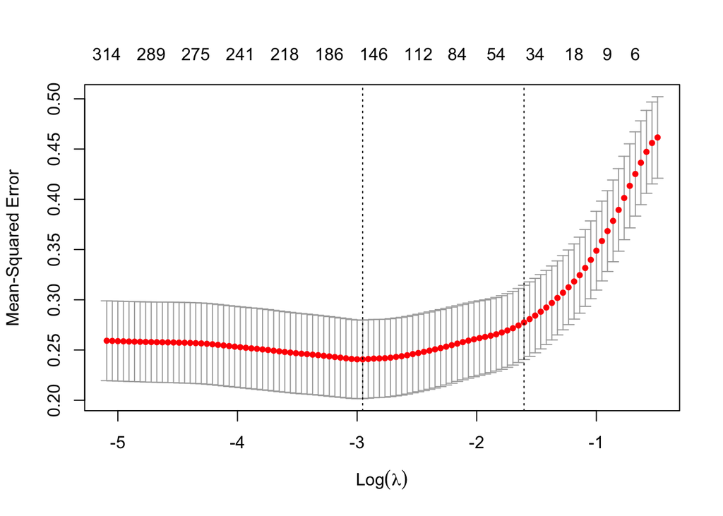

```r
# I used "alpha = 0.5"

Enet_mod_11b <- glmnet(X_train, Y_train, alpha = 0.5, lambda = grid)

cv_out_11b <- cv.glmnet(X_train, Y_train, alpha = 0.5)
plot(cv_out_11b)
```

```r
best_lam_11b <- cv_out_11b$lambda.min

Enet_pred_11b <- predict(Enet_mod_11b, s = best_lam_11b, newx = X_test)
test_error_Enet_11b <- mean((Enet_pred_11b - Y_test)^2)

out_11b <- glmnet(X_scaled, Y, alpha=1)
Enet_coef_11b <- predict(out_11b, type="coefficients",
                          s=best_lam_11b)[-1, ]

Enet_coef_11b[Enet_coef_11b !=0]
```

```
##         ACYP2      ARHGAP19         BCAS2      C10orf76      C17orf53
## -2.537380e-03  1.357931e-02 -4.864008e-03  2.612960e-02  1.533024e-02
##       C3orf10       C4orf14         CBLN3        CCDC56          CDC6
## -2.674072e-02 -8.645325e-03  4.734326e-03  5.358397e-02  1.689190e-03
##       CEACAM8         CENPK         CENPM         CENPQ        CHTF18
##  1.538505e-02  2.287237e-02  1.016349e-02  3.194791e-02  1.270580e-02
##           CLC         CMTM5          COQ5          CRBN         DARS2
##  7.933775e-03 -3.296632e-02  1.001509e-02 -3.930670e-04  4.801047e-03
##         DDX52         DMRT3           DTL         EIF1B         ESCO2
##  7.273408e-03 -9.827179e-03  6.627354e-02 -1.942705e-02  6.030987e-04
##      FAM103A1        FGFRL1      FLJ10241         GINS1          HECA
## -8.650650e-05 -2.117777e-03  1.874273e-02  6.570023e-03 -3.990846e-03
##      HISPPD2A          HMMR       HSP90B1       KHDRBS1      KIAA0101
##  9.022338e-03  6.153396e-03  9.252278e-04  4.375206e-02  9.844690e-03
##        KLHL13          MCM6         MFGE8          NBR2        NFATC1
## -3.537448e-02  3.415186e-02 -7.170219e-05  2.024793e-01 -1.617779e-02
##          NLE1         NMUR1         PCGF1         PPM1B      PPP1R16B
##  2.211594e-03 -1.975721e-03 -1.456489e-03 -9.035964e-03 -4.891217e-03
##         PSME3         RC3H2          RFX1         RPL27        SETMAR
##  4.626873e-02 -5.314523e-03  2.422493e-04  3.570746e-02 -8.393647e-03
##      SLC25A22         SPAG5      SPINK5L3         SUZ12        SYNGR4
##  1.221155e-02  3.854831e-02  1.556742e-02  1.408366e-05  1.114908e-02
##        TADA3L         THOC2       TMPRSS4         TOP2A         TRAIP
## -1.050252e-02  3.593010e-03  1.566014e-02  4.508395e-02  6.796437e-03
##        TSPYL2        TUBA1B         VDAC1         VPS25        WDR51A
## -7.786517e-03  3.581295e-02  1.055187e-02  3.244659e-02  7.940014e-03
##         XRCC2        YTHDC2        ZNF189        ZNF592
##  2.176070e-02  1.768921e-02 -8.033491e-03 -1.262491e-02
```

```r
nonzero_Enet <- length(Enet_coef_11b[Enet_coef_11b !=0])

cat("Lasso Test Error:", test_error_Enet_11b,
    "Lasso Non-zero Coefficients:", nonzero_Enet, "\n")
```

```
## Lasso Test Error: 0.2221951 Lasso Non-zero Coefficients: 69
```

### (c)

3. Fit an adaptive lasso model on the training set. Report the test error obtained, along with the number of non-zero coefficient estimates.

```r
# fit an initial Lasso model to obtain coefficient estimates
lasso_model_11c <- cv.glmnet(X_train, Y_train, alpha = 1)
lasso_coef_11c <- coef(lasso_model_11c, s =lasso_model_11c$lambda.min)[-1]

weights <- 1 / (abs(lasso_coef_11c) + 1e-6)  # avoid 0

alasso_model_11c <- cv.glmnet(X_train, Y_train, alpha = 1, penalty.factor = weights)

alasso_pred_11c <- predict(alasso_model_11c,
                           s = alasso_model_11c$lambda.min, newx = X_test)
test_error_alasso <- mean((alasso_pred_11c - Y_test)^2)

alasso_coef_11c <- coef(alasso_model_11c, s = alasso_model_11c$lambda.min)[-1, ]
alasso_coef_11c[alasso_coef_11c!=0]
```

```
##        ABCC1       ALOX12     ARHGAP19        ARIH1     C12orf59      CEACAM8
##  0.026983893  0.047130901  0.057041159 -0.088696180  0.023132343  0.065706680
##        CENPQ        CEP72        CNTN1       COL9A2          DTL       FBXL13
##  0.056482381  0.034929330 -0.030678285 -0.045609105  0.096961940  0.070311755
##     FLJ20294         HAO1    HIST1H2AD         HMMR         HSF5       INPP5F
##  0.042577554 -0.061629269 -0.054434152  0.073681957 -0.013391972 -0.051203241
##        IPO13       KBTBD5      KHDRBS1         KIF6       KLHL13         KNG1
## -0.026534539  0.031267470  0.049684176  0.010673624 -0.014575315  0.009708955
##       MAP7D2          MBP         MCM6       MRPL39         NBR2       NCAPG2
##  0.035545345 -0.059905751  0.097149261 -0.028926181  0.195039502  0.013291502
##       NFATC1         NMT1        OR5J2      PRAMEF1        PSME3      RASGRP4
## -0.034574834  0.034062781  0.013341231  0.006948278  0.145817198  0.001520710
##       RNF149        SEC13      SLITRK2       TAGLN3        TOP2A       TRMT11
##  0.071378576 -0.022022527 -0.036242685 -0.028185582  0.046918166 -0.100640960
##        VPS25        WDR23        XRCC2         ZZZ3
##  0.048010955 -0.021510060  0.007301274 -0.068872217
```

```r
nonzero_alasso <- length(alasso_coef_11c[alasso_coef_11c!=0])

cat("Adaptive LASSO Test Error:", test_error_alasso,
    "Non-zero Coefficients:", nonzero_alasso, "\n")
```

```
## Adaptive LASSO Test Error: 0.2373069 Non-zero Coefficients: 46
```

### (d)

4. Fit a SCAD model on the training set. Report the test error obtained, along with the number of non-zero coefficient estimates.

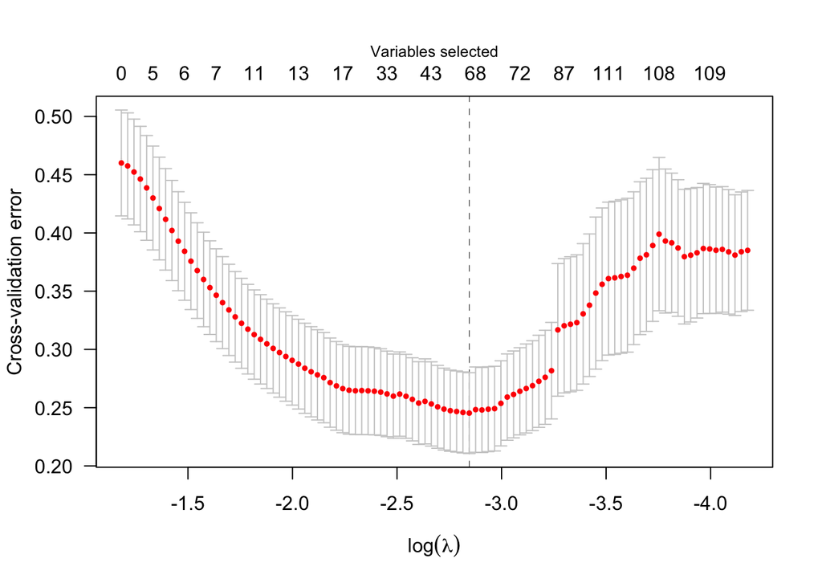

```r
cv_out_11d <- cv.ncvreg(X_train, Y_train, family="gaussian", penalty="SCAD")
plot(cv_out_11d)
```

```r
best_lam_11d <- cv_out_11d$lambda.min

SCAD_mod_11d <- ncvreg(X_train, Y_train, family = "gaussian", penalty = "SCAD")
SCAD_pred_11d <- predict(SCAD_mod_11d, lambda=best_lam_11d, X = X_test)
test_error_SCAD_11d <- mean((SCAD_pred_11d - Y_test)^2)

out_11d <- ncvreg(X_scaled, Y, family="gaussian", penalty="SCAD")
SCAD.coef <- predict(out_11d, type="coefficients",
                     lambda=best_lam_11d)[-1,]

SCAD.coef[SCAD.coef!=0]
```

```
##        ABHD13        ALOX12      ANKRD13B      C10orf76      C19orf56
## -0.0134719379  0.0002974963  0.0005605553  0.0294602154 -0.0021013957
##       C3orf10       C4orf14         CENPQ           CLC         CMTM5
## -0.0129570753 -0.0005691878  0.0077101574  0.0086207266 -0.0121741103
##       COL20A1          CRBN          DARS         DDX52  DKFZp779O175
##  0.0023176040 -0.0273345444  0.0084038209  0.0078092801  0.0042559617
##           DTL        FGFRL1          GNL1     HIST1H2BL     HIST2H2BE
##  0.3034925432 -0.0134316426 -0.0137797261 -0.0023456886 -0.0166054575
##       HSP90B1         ITPKB       KHDRBS1      KIAA1542        KLHL13
##  0.0083305259 -0.0008355584  0.0307033904  0.0143622666 -0.0246423443
##          KSR1        MAGEF1          NBR2          NLE1         NUDT1
##  0.0101262242 -0.0011556926  0.2908448720  0.0051116331  0.0017681643
##         PPM1B         PRDM8        RASL12        RNF149         RPL27
## -0.0040406890  0.0025800969 -0.0032524869  0.0020838548  0.0218623729
##        SETMAR      SLC25A22         SNRPF         SPAG5      SPINK5L3
## -0.0178670132  0.0084699373  0.0043223968  0.0158638685  0.0035061864
##          SYCN           TKT        TMEM97       TMPRSS4         TRAIP
##  0.0051393757  0.0059463466  0.0034555946  0.0172671062  0.0006545073
##  TRIM6-TRIM34        TUBA1B          UTP6         VDAC1         VPS25
##  0.0015438436  0.0235144230  0.0068800592  0.0089345568  0.1297918133
##        YTHDC2        ZBTB26        ZNF189        ZNF510         ZNF77
##  0.0142733014 -0.0017093383 -0.0141241517 -0.0006299110 -0.0034677188
```

```r
nonzero_SCAD <- length(SCAD.coef[SCAD.coef!=0])

cat("SCAD Test Error:", test_error_SCAD_11d,
    "SCAD Non-zero Coefficients:", nonzero_SCAD, "\n")
```

```
## SCAD Test Error: 0.226472 SCAD Non-zero Coefficients: 55
```

### (e)

5. Fit an MCP model on the training set. Report the test error obtained, along with the number of non-zero coefficient estimates.

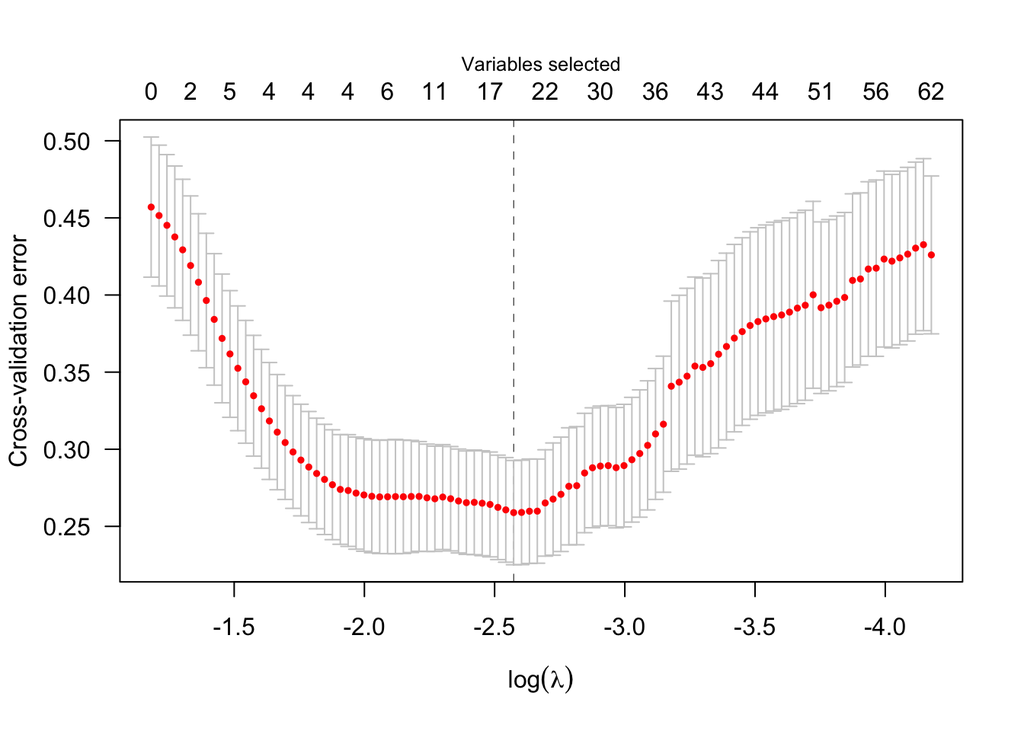

```r
cv_out_11e <- cv.ncvreg(X_train, Y_train, penalty = "MCP")
plot(cv_out_11e)
```

```r
best_lam_11e <- cv_out_11e$lambda.min

MCP_mod_11e <- ncvreg(X_train, Y_train, family = "gaussian", penalty = "MCP")
MCP_pred_11e <- predict(MCP_mod_11e, lambda=best_lam_11e, X = X_test)
test_error_MCP_11e <- mean((MCP_pred_11e - Y_test)^2)

out_11e <- ncvreg(X_scaled, Y, penalty = "MCP")
MCP.coef <- predict(out_11e, type = "coefficients",
                     lambda = best_lam_11e)[-1, ]

MCP.coef[MCP.coef!=0]
```

```
##        ABHD13      C10orf76         CMTM5          CRBN           DTL
## -0.0108039039  0.0060805550 -0.0020050296 -0.0256497787  0.2914464146
##        FGFRL1          GNL1     HIST2H2BE       HSP90B1       KHDRBS1
## -0.0186836410 -0.0042448525 -0.0245877312  0.0003584568  0.0368578708
##        KLHL13          NBR2        SETMAR      SLC25A22         SPAG5
## -0.0235987445  0.2949145414 -0.0347984183  0.0083868117  0.0720247968
##          SYCN         VPS25        YTHDC2
##  0.0052306623  0.1677980478  0.0024746809
```

```r
nonzero_MCP <- length(MCP.coef[MCP.coef!=0])

cat("MCP Test Error:", test_error_MCP_11e,
    "MCP Non-zero Coefficients:", nonzero_MCP, "\n")
```

```
## MCP Test Error: 0.2267597 MCP Non-zero Coefficients: 18
```

### (f)

6. Fit an ISIS model on the training set. Report the test error obtained, along with the number of non-zero coefficient estimates.

```r
model_ISIS <- SIS(X_train, Y_train, family = 'gaussian', penalty = 'MCP',
                  tune = 'cv', nfolds = 10, seed = 31)
```

[output not shown]

```r
best_lam_11f <- model_ISIS$lambda
ISIS.pred <- predict(model_ISIS, newx = X_test,
                     lambda = best_lam_11f, type = "response")
test_error_ISIS_11f <- mean((ISIS.pred - Y_test)^2)

out_11f <- SIS(X_scaled, Y, family='gaussian', penalty = 'MCP')
```

[output not shown]

```r
ISIS.coef<-predict(out_11f, type = "coefficients", lambda = best_lam_11f)[-1, ]

ISIS.coef[ISIS.coef!= 0]
```

```
##        ANLN        ASPM       ATAD5       BECN1    C10orf76      CCDC43
##  0.08012849  0.05213654 -0.06049575  0.05395610  0.07613566 -0.07226057
##       CDCA2       CENPQ      CEP152         CIT        CRBN       DDX52
##  0.03105989  0.07409092 -0.02069331  0.04538770 -0.12829286  0.06548943
##     DEPDC1B         DTL      FGFRL1      GAS2L3       GMEB1   HIST2H2BE
## -0.07650435  0.15135310 -0.07963866 -0.02126221  0.05413562 -0.07541785
##        HMMR     HSP90B1     KHDRBS1      KLHL13        MCM6       MFGE8
##  0.06966269  0.05036448  0.01891113 -0.06095204  0.08592236 -0.05509253
##        MND1    MPHOSPH1        NBR2      NPEPPS        OIP5       PTCD2
##  0.04763075  0.06368601  0.24377227  0.05811030  0.08669440  0.06687593
##       PTTG3     RACGAP1       SPAG5    TIMELESS      TMEM97       TOP2A
## -0.11728831 -0.09743027  0.03946564 -0.05090473  0.01063125  0.03288207
##       TRAIP         TTK      TUBA1B       VPS25      YTHDC2
##  0.04826146 -0.06544104  0.07725765  0.15968317  0.04287875
```

```r
nonzero_ISIS <- length(ISIS.coef[ISIS.coef!= 0])

cat("ISIS Test Error:", test_error_ISIS_11f,
    "ISIS Non-zero Coefficients:", nonzero_ISIS, "\n")
```

```
## ISIS Test Error: 0.2750978 ISIS Non-zero Coefficients: 41
```